# Chicago Public Health and Socioeconomic Analysis

Cisse Amina

2024-12-11

## **Introduction**

**How do socioeconomic factors correlate with health outcomes across Chicago’s community areas & mortality rates?**

In this project, I aim to explore the relationship between socioeconomic factors and health outcomes in Chicago, focusing on community areas with varying levels of socioeconomic status (SES). Specifically, I hypothesize that neighborhoods with lower SES, as measured by per capita income and unemployment rate, will exhibit poorer health outcomes, including higher mortality rates.

Chicago, like many major urban centers in the U.S., has significant disparities in both socioeconomic conditions and health outcomes across its neighborhoods. Lower-income communities, often located on the South and West sides of the city, face challenges such as limited access to healthcare, higher rates of chronic diseases, and lower life expectancies. These disparities are exacerbated by factors like housing quality, environmental conditions, and historical disinvestment in these areas.

The analysis includes a range of health indicators such as infant mortality rates, prenatal care initiation, and childhood lead poisoning rates, which I will analyze in relation to socio-economic variables. To test this hypothesis, I will use multiple regression analysis and other statistical methods to examine how these factors influence health outcomes across Chicago’s community areas. The findings of this research are expected to provide valuable insights into the role that socioeconomic conditions play in shaping public health, with potential implications for policy interventions aimed at addressing these disparities.

## **Statistics Analysis**

Regression Results: Infant Mortality Rate vs. Socioeconomic Factors

| term | Coefficients estimate | Coefficients std.error | Coefficients statistic | Coefficients p.value |
| --- | --- | --- | --- | --- |
| (Intercept) | 0.877 | 1.566 | 0.560 | 0.577 |
| `Per Capita Income` | 0.000 | 0.000 | 0.754 | 0.453 |
| `PERCENT AGED 16+ UNEMPLOYED` | 0.464 | 0.060 | 7.735 | 0.000 |

The regression model accounts for 55.49% of the variance in infant mortality rates across Chicago’s community areas, implying a moderate degree of correlation.

This suggests that per capita income and unemployment rate together account for over half of the variability in infant mortality rates across Chicago community areas. Overall Significance: The regression is statistically significant (F-statistic = 46.13, p-value = 9.805e-14), indicating that the predictors collectively have a significant effect on infant mortality rates.

In conclusion, the analysis reveals that unemployment rate is a strong predictor of infant mortality rates in Chicago community areas, while per capita income does not show a significant independent effect. This suggests that policies aimed at reducing unemployment might be more effective in lowering infant mortality rates than those focused solely on increasing income levels.

## **VisualizationAnalysis**

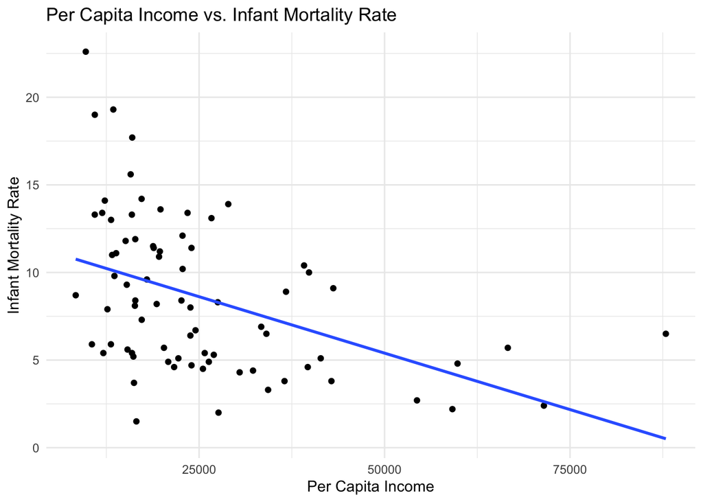

The scatter plot shows a negative correlation between per capita income and infant mortality rate (correlation coefficient: -0.52). This supports our hypothesis that lower-income areas tend to have poorer health outcomes (here so higher infant mortality rates.)

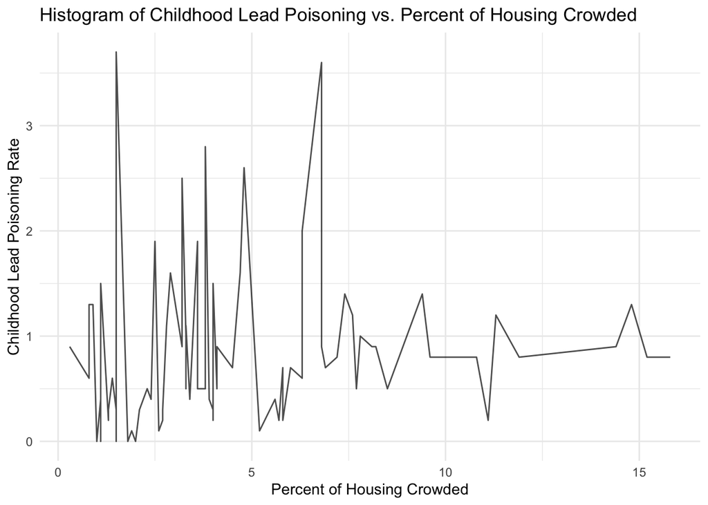

The line graph explores the relationship between childhood lead poisoning rates and the percentage of housing that is crowded. The data appears erratic, with sharp spikes and drops in lead poisoning rates across varying levels of housing crowding. This lack of a clear trend indicates that crowding alone may not be the primary factor influencing lead poisoning rates. Other variables, such as the age of housing, environmental policies, or localized sources of lead exposure, may play a more significant role.

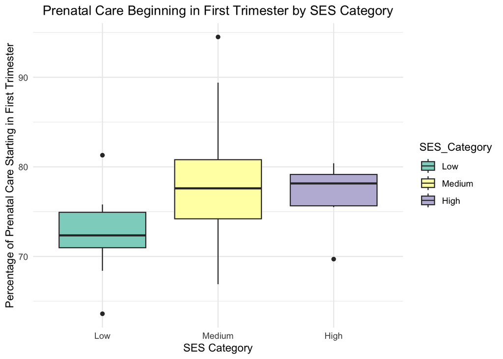

Summary Statistics: Prenatal Care by SES Category

| SES_Category | Mean_Prenatal_Care | Median_Prenatal_Care | Count |
| --- | --- | --- | --- |
| Low | 72.53 | 72.35 | 12 |
| Medium | 77.88 | 77.60 | 57 |
| High | 77.00 | 78.15 | 8 |

Community areas with lower socioeconomic status (SES) have significantly less access to early prenatal care. The average percentage of prenatal care starting in the first trimester is 72.53% in low SES areas, lower than the 77.88% in medium SES and 77.00% in high SES areas. Median values reflect similar trends, with low SES areas at 72.35%, compared to 77.60% in medium and 78.15% in high SES areas.

There are 12 low SES areas, 57 medium SES areas, and 8 high SES areas, indicating a disproportionate representation of medium SES communities.

These findings support the hypothesis that lower SES correlates with reduced access to early prenatal care, suggesting a health disparity that may negatively impact maternal and child health. The analysis underscores the need for targeted public health interventions to improve prenatal care access in low SES areas, potentially through increased resources, outreach programs, and support systems for expectant mothers.

## **Map visualization**

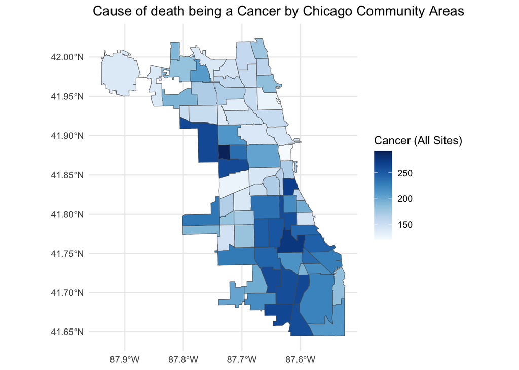

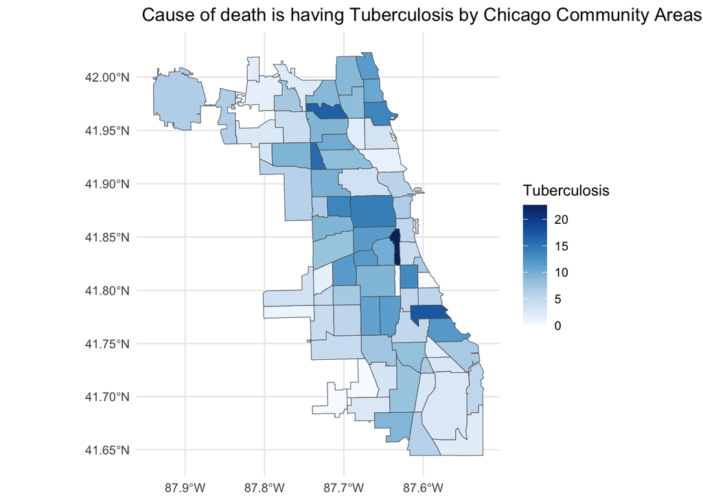

I used spatial mapping to visualize health outcomes, such as tuberculosis and cancer mortality rates, across different Chicago community areas. The color intensity on the maps reflects the concentration of these health outcomes in each community area

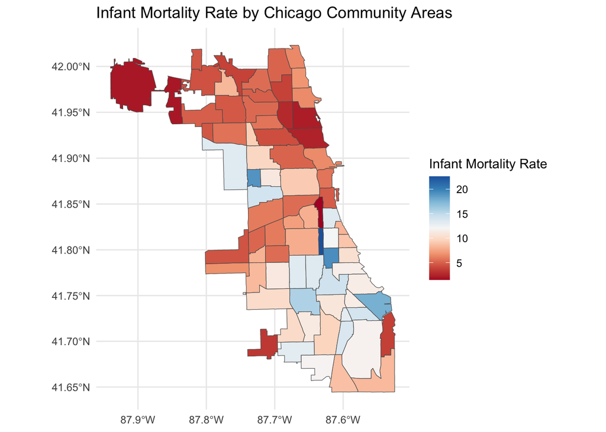

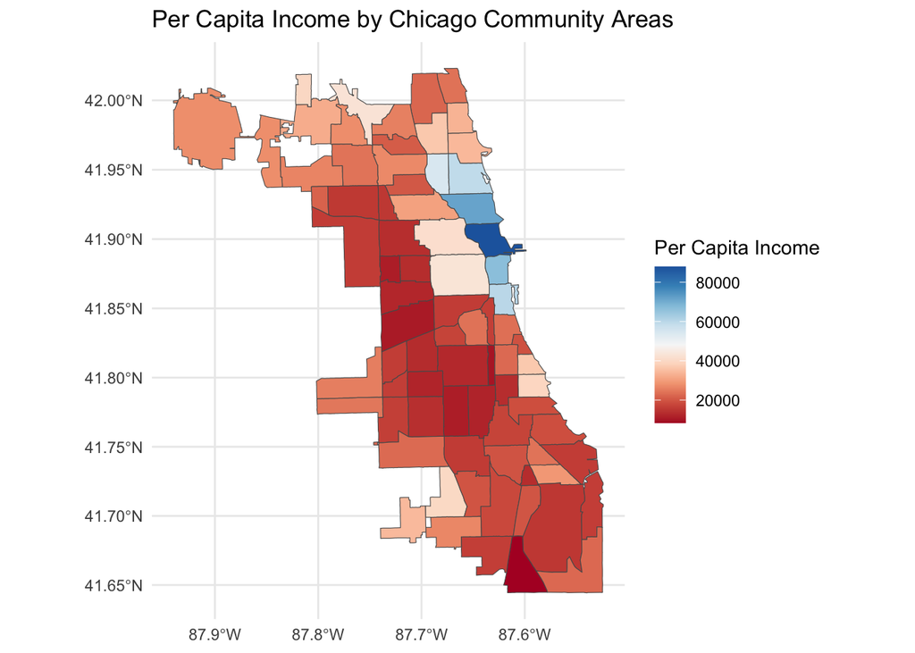

The map visualization reveals a clear spatial pattern of income distribution across Chicago, with higher-income areas concentrated along the lakefront and in the northern parts of the city.

## **Summary**

Furthermore the analysis clearly shows that community areas with lower socioeconomic status have significantly lower rates of prenatal care beginning in the first trimester compared to those with medium and high socioeconomic status. This finding underscores the need for targeted public health interventions aimed at improving access to prenatal services in lower SES communities to enhance maternal and infant health outcomes, also should focus on reducing focusing unemployment. This may have a more significant effect on improving health outcomes.

Addressing these disparities is crucial for promoting health equity across Chicago’s diverse neighborhoods.